# Programming for Data Science 2024

## Homework Assigment Three

Homework Assigment Three focus in the step-by-step implementation of a simple, yet popular, clustering algorithm, the K-Means. Although in most projects you will source algorithms from libraries such as scikit-learn or Keras, in other cases you will need to implement an algorithm yourself. For instance, if such algorithm is not available or if you want to tailor the algorithm to your problem. In that sense, learning to implement algorithms is an important part of your skillset.

This is an Individual assingment, students that are caught cheating will obtain a score of 0 points.  
The Homeworking Assignment Three is worth 10% of your final grade.

The submission package should correspond to a .zip archive (.rar files are not acceptable) with the following files:

1. Jupyter Notebook with the output of all the cells;
2. HTML print of your Jupyter Notebook;
3. All files outputed as part of the exercises.

The .zip archive filename should be student1ID_student2ID.

Your submission will be graded according to the following guidelines:

1. Execution (does your program does what is asked from the exercise?)
2. Objectivity (are you using the adequate libraries?)
3. Readibility of your code (that includes comments, naming of variables, supporting text, etc ...)

In some questions might require that you make critical decisions, or design choices. In such cases, you will be graded according also for your ability to justify and support your decisions.

**Comment your code properly, which includes naming your variables in a meaningful manner. Badly documented code will be penalized.**

Submission is done through the respective Moodle activity. Deadline is November 2nd at 12:00. A penality of 1 point per day late will be applied to late deliveries, with a maximum of 5 days.

Please fill the following fields:  
**Name**: Elcano Gaspar  
**ID**: 20241021

**Name**: Tahiya Jahan Laboni  
**ID**: 20240943

## Clustering with K-Means

K-Means is one of the most popular "clustering" algorithms, which you perhaps are already familiar from the Data Mining curricular unit. K-means estimates the location of $k$ centroids that it uses to define clusters. A point is considered to be in a particular cluster if it is closer to that cluster's centroid than any other centroid.

The K-means Algorithm consists in an iterative process that is roughly as follows:

1. Choose value for K (number of clusters);
2. Initialize the locations of the centroids, which we can do by randomly select K points from your dataset as initial locations of the centroids;
3. Calculate distance of all other points to each of the K centroids;
4. Associate each point to the cluster of the closest centroid;
5. Update the centroid position, by computing the average coordinates of all points associated to each cluster;
6. Evaluate the average change in the centroids positions, as a measure of convergence (the algorithm is said to have converged to the solution when the positions of the centroids don't change more than a given tolerance threshold);
7. Repeat steps 3-6 until either the centroids no longer move more than a tolerance threshold or until you repeated these steps at least for specified number of iterations (niter)

The algorithm is thus parametized by the number of clusters (K), the maximum number of iterations (niter), and the tolerance threshold (tol).

### Step 1

Let us start by importing the necessary libraries to execute this homework.  
Import numpy, Scipy, and pandas using, respectively, the aliases np, sc, and pd.

```python
import numpy as np
import scipy as sc
import pandas as pd
```

It is important that we devise a strategy to test our code at each step, in order to assess if it performs as expected. To that end, we have split each step of the algorithm into different blocks, and we ask you to test each block against a simple scenario where the outcome is predictable and can be computed by hand. In some steps, however, we want to pass a more comprehensive dataset with similar properties to the real dataset that we will be working with.

Such, test datasets try to create realistic conditions in which your algorithm is expected to work correctly, and for which we can also assess if the solution matches our expectation. This allows us to have a general understanding if the algorithm performs as expected in "real-world" conditions.

For this homework we will resort to a dataset that contains two clearly distinct clusters. We generated the clusters by sampling points from two distinct gaussian distributions with different averages and same standard deviation.  
As such, our algorithm should be able to identify each cluster easily, and place the centroids close to the averages of the two distributions.

Run the cell below to download, load the data into a numpy array, and visualize your Test dataset.  
You will run your algorithm implementation against this dataset as a proof of work.

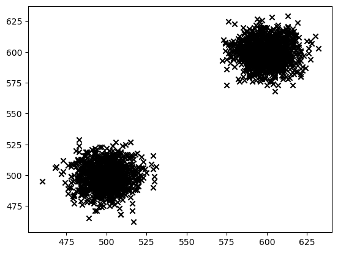

```python
import pandas as pd
import matplotlib.pyplot as plt

# download the file into a dataframes and convert it to a numpy array.
data_test = pd.read_csv("https://www.dropbox.com/s/gax1l68jsarxqt9/data_test.txt?dl=1", header=None).to_numpy()

#plot the points into a scatter plot
plt.scatter(data_test[:, 0], data_test[:,1], color ='k', marker='x')
```

**Optional Challenge:** Can you write a function that generates an artificial dataset for testing purposes?  
We will award one extra point for students that offer a good implementation.

**Consider leaving this challenge to the very end of the assignment**

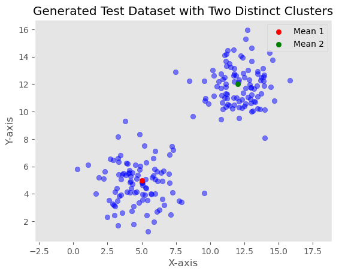

```python
def generate_test_data(mean1, mean2, std, n_samples=100, seed=12):
    # Set the random seed for reproducibility
    if seed is not None:
        np.random.seed(seed)

    # Ensure the distance between means is at least 2 * std
    distance = np.linalg.norm(np.array(mean1) - np.array(mean2))
    if distance < 2 * std:
        raise ValueError("The distance between means must be at least 2 * standard deviation.")

    # Generate points for two clusters
    points_cluster1 = np.random.normal(loc=mean1, scale=std, size=(n_samples // 2, 2))
    points_cluster2 = np.random.normal(loc=mean2, scale=std, size=(n_samples // 2, 2))

    # Combine both clusters into one array
    points = np.vstack((points_cluster1, points_cluster2))
    return points

mean1 = (5, 5)
mean2 = (12, 12)
std = 1.5
n_samples = 200

try:
    test_data = generate_test_data(mean1, mean2, std, n_samples)

    # Plot the generated data points
    plt.scatter(test_data[:, 0], test_data[:, 1], c='blue', alpha=0.5)
    plt.scatter(*mean1, c='red', label='Mean 1')
    plt.scatter(*mean2, c='green', label='Mean 2')
    plt.xlabel("X-axis")
    plt.ylabel("Y-axis")
    plt.legend()
    plt.title("Generated Test Dataset with Two Distinct Clusters")
    plt.axis('equal')
    plt.grid()
    plt.show()
except ValueError as e:
    print(e)
```

### Step 2

Write a function named **init** that takes two arguments: $points$ and $K$.  
The function **init** should return a numpy ndarray with $K$ elements sampled randomly and without replacement from $points$. Meaning, the same point cannot picked up twice.

**Show that your function performs as desired by calling it with** $K = 2$ **and use data_test as the** $points$

```python
# Initializes K centroids by randomly selecting K points from the dataset without replacement.
def init(points, k):
    # Check if k is less than the number of points to avoid errors
    if k > points.shape[0]:
        raise ValueError("Number of centroids (k) must be less than or equal to the number of points.")
    return np.random.choice(points.shape[0], size=k, replace=False)
```

```python
print(init(data_test, 2))
```

```
[1914   72]
```

### Step 3

Write a function named **distance** that takes two arguments: $p1$ and $p2$.  
The function **distance** should return a scalar that corresponds to the euclidean distance between points $p1$ and $p2$, that should have a ndarray format.  
Assume that $p1$ and $p2$ are two ndarrays of the same size.

Recall that the euclidian distance (d) between two points ($p_1$ and $p_2$) in a 2-dimensional space is given by:  
\begin{equation} d(p_1, p_2) = \sqrt{(x_1-x_2)^2 + (y_1-y_2)^2 } \end{equation}  
where $p_1 = \{x_1,y_1\}$ and $p_2 = \{x_2,y_2\}$.

**1) Test that your function works by computing the distance between p1=(1,3) and p2=(7,2), which is $\approx$ 6.08.**  
**Consider using the existing Numpy or Scipy packages for this task.**

Can you write a function that computes the euclidean distance between two points of arbitrary dimension?  
In general, for arbitrary dimensionality the square of the distance can be computed as:  
\begin{equation} d^2(p_1, p_2) = \sum_{i=0}^{D-1} (x_i-y_i)^2 \end{equation}  
where $p_1 = \{x_1,x_2,...,x_{D-1}, x_D\}$ and $p_2 = \{y_1,y_2,...,y_{D-1},y_D\}$.

**2) Show that your function works by computing the distance between (1,3,-9,12) and (7,2,0,5)**

***1)***

```python
def distance(p1, p2):
    # Ensure the input points are numpy arrays for element-wise operations
    p1 = np.asarray(p1)
    p2 = np.asarray(p2)

    # Return the square root of the sum to obtain the Euclidean distance
    return np.linalg.norm(p1 - p2)
```

```python
#Test variables, do not change the values
p1 = np.array([1,3])
p2 = np.array([7,2])
```

```python
print("Distance between p1 and p2 for test 1 and expected output (should be ≈ 6.08): ", distance(p1,p2))
```

```
Distance between p1 and p2 for test 1 and expected output (should be ≈ 6.08):  6.082762530298219
```

***2)***

```python
#Test variables, do not change the values
p1 = np.array([1,3,-9,12])
p2 = np.array([7,2,0,5])
```

```python
print("Distance between p1 and p2 for test 2 : ", distance(p1,p2))
```

```
Distance between p1 and p2 for test 2 :  12.922847983320086
```

### Step 4

Write a function **centroid_update** that takes two input arguments: *points* and *clusters*  
The argument *points* is a ndarray containing the coordinates of a set of points (1 point per row). The argument *clusters* is a 1-dimensional ndarray that indicates the cluster to which each point is associated. Note that values in *clusters* are integers and can only take values between 0 and K-1, where K is the number of clusters.

The function **centroid_update** should return an ndarray with the average coordinates of the points associated to each cluster, that is the centroid of each cluster. The returned array should have the same number of columns as points and length K.

**Test your function and report the centroids generated by passing p and c as inputs with k = 3. Save these centroids as a variable: cen**

```python
def centroid_update(points, clusters):
    # Number of clusters define, assuming clusters are labeled from 0 to k-1
    k = np.max(clusters) + 1
    # print(k)
    # Define initial centroids array, and value are 0 initially
    centroids = np.zeros((k, points.shape[1]))
    # print("initial centroids", centroids)
    for k in range(k):
        # print("k and clusters", k,clusters)
        # select points in clusters k
        cluster_points = points[clusters == k]
        if len(cluster_points) > 0: # Avoid division by zero if a cluster has no points
            centroids[k] = np.mean(cluster_points, axis=0)
    return centroids
```

```python
# Tesst variables, do not change the values
p = np.array([[0.8922063, 0.26672425],[0.34475611, 0.35976697],[0.33253499, 0.18923898],[0.66872466, 0.46248986],[0.72823733, 0.10537784],[0.40903598, 0.70639412],[0.79926596, 0.90095583],[0.67886544, 0.84573289],[0.3641813, 0.64296743],[0.07461196, 0.74290527]])
c = np.array([2, 0, 0, 1, 1, 0, 0, 1, 0, 1])
```

```python
print("Centroids:\n", centroid_update(p, c))
```

```
Centroids:
 [[0.44995487 0.55986467]
 [0.53760985 0.53912646]
 [0.8922063  0.26672425]]
```

### Step 5

Write a function **points_update** that takes two input arguments: $points$ and $centroids$.  
The function **points_update** should return a one-dimensiona ndarray that indicates the index of the centroid that is closer to each point. To determine the distance between a centroid and a point you can use your distance function you created earlier.

You will need to assess the distance between each point to each centroid. Different approaches can be taken to do this. For instance, you can start by computing a d by k distance matrix matrix between each of the $d$ points and the $k$ centroids.

**Test your function by calling it and passing the array p (as defined above) with the output of cupdate, cen, as arguments. You should get an output that looks like c defined above (but is not exactly the same, can you see why). Print this result and save it in a variable called new_clusters**

```python
def points_update(points, centroids):
    closest_centroid = []

    # interate over each point
    for point in points:

        # Compute the distance between the current poin and each centroid
        distances = np.array([distance(point, centroid) for centroid in centroids])

        # find the index of nearest centroid
        closest_centroid_index = np.argmin(distances)

        # append this to the list
        closest_centroid.append(closest_centroid_index)

    # convert the list into np array
    return np.array(closest_centroid)
```

```python
# calculate centroids
cen = centroid_update(p, c)

# update clusters with new centroids
new_cluster = points_update(p, cen)
print("New cluster", new_cluster)
```

```
New cluster [2 0 0 1 2 0 1 1 0 0]
```

### Step 6

Write a function **error** that takes two input arguments: oldcentroids and newcentroids.  
The argument oldcentroids corresponds to a ndarray with centroid positions from the previous iteration, and newcentroids to a ndarray with the newly computed centroid positions from the current iteration.

The function **error** should return the average euclidean distance between the old and new positions of each centroid. This will give us a quantity that tell us whether our algorithm is still converging to the solution or got to good approximation. We will use a tolerance threshold in the average change in the centroids positions to make this decision.

**Test your function then report the distance between the centroids calculated in Step 5, cen, and the centroids that you can calculate using the function cupdate with the arguments points and new_clusters.**

```python
def error(oldcentroids, newcentroids):
    avg_euclidean = []
    # interate over each centroid
    for i in range(len(oldcentroids)):
        #compute the euclidean distance
        dist = distance(oldcentroids[i],newcentroids[i])
        avg_euclidean.append(dist)
    # return the average distance between centroids
    return np.mean([avg_euclidean])
```

```python
# Using the previously defined function to calculate new centroids
newcentroids = centroid_update (p, new_cluster)
print(error(cen, newcentroids))
```

```
0.17635560837965428
```

### Step 7

Write a wrapper function called **kmeans** that takes the following arguments:

- $points$, which is a ndarray of points;
- $K$, the number of clusters, set the default value to two;
- $niter$, the number of iterations;
- $tol$, the error tolerance threshold below which your algorithm should stop

The function should return:

- A one dimensional ndarray with the cluster of associated to each point,
- A ndarray with the location of the K centroids.

Use the functions you prepared in the previous Steps to assemble the function **kmeans**.  
Use the tolerance as a treshold to stop the algorithm, for instance by evaluating if the average variation in the distance between the new and previous coordinates of the centroids is below the tolerance level. If yes, then you can stop the algorithm and return the outputs.

You will need to make some decisions about the best approach to select the correct range of values to pass to init(). Explain how you did it.

**Note: A common issue with the K-means algorithm is that in some limiting conditions it might lead to empty clusters. In that case it is expected that your algorithm to return errors. Although that is not expected to happen with the examples provided, you might want to consider implementing some heuristics to overcome those errors. However, such is an optional task, and for this homework if you bump into such errors we recommend you try to rerun your code.**

```python
# Using previous functions: distance, centroid_update, points_update, and error
""" For this exercise, specific values for `niter` and `tol` were not given, so reasonable defaults can be used, e.g., `niter = 100` and `tol = 1e-4`.
# You may adjust these values based on data size and clustering requirements.
"""
def kmeans(points, k=2, tol=1e-4, niter=100):
    # Step 1: Initialize centroids randomly from the points
    centroids = points[np.random.choice(points.shape[0], k, replace=False)]

    # Step 2: Initialize variables for tracking iteration and convergence
    prev_centroids = np.zeros_like(centroids)
    iter_count = 0

    # Iterate until convergence or maximum iterations reached
    while np.linalg.norm(centroids - prev_centroids) > tol and iter_count < niter:
        # Step 3: Assign each point to the closest centroid
        distances = np.linalg.norm(points[:, np.newaxis] - centroids, axis=2)
        clusters = np.argmin(distances, axis=1)

        # Step 4: Store current centroids and compute new centroids
        prev_centroids = centroids.copy()
        centroids = np.array([points[clusters == i].mean(axis=0) for i in range(k)])

        # Increment iteration counter
        iter_count += 1

    return clusters, centroids
```

```python
# Testing the function
clusters, centroids = kmeans(p, k=3, niter=100, tol=0.01)
print("Clusters:", clusters)
print("Centroids:", centroids)
```

```
Clusters: [0 0 0 0 0 2 1 1 2 2]
Centroids: [[0.59329188 0.27671958]
 [0.7390657  0.87334436]
 [0.28260975 0.69742227]]
```

It is useful to visually inspect the results in order to assess the performance of the clustering algorthim.  
Below is an example of how you can visualize your results for a sample dataset.  
Can you adapt the code to show your results applied to data_test with K = 2, niter = 500, tol = 0.00001.

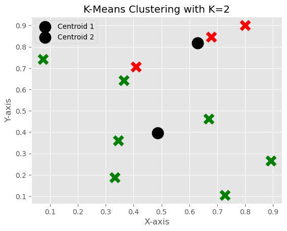

```python
#boilerplate
import numpy as np
import matplotlib.pyplot as plt
from matplotlib import style

# Define plot style and colors
style.use('ggplot')
colors = ["g", "r", "c", "b"]  # Define colors for clusters

# Assume data_test is defined
data_test = np.array([[0.8922063, 0.26672425], [0.34475611, 0.35976697],
                      [0.33253499, 0.18923898], [0.66872466, 0.46248986],
                      [0.72823733, 0.10537784], [0.40903598, 0.70639412],
                      [0.79926596, 0.90095583], [0.67886544, 0.84573289],
                      [0.3641813, 0.64296743], [0.07461196, 0.74290527]])

# Define parameters for K-means
k = 2
niter = 500
tol = 0.00001

# Run the K-means algorithm (assume kmeans function is defined)
clusters, centroids = kmeans(data_test, k=k, niter=niter, tol=tol)

# Visualize the clustering results
for i, centroid in enumerate(centroids):
    plt.scatter(centroid[0], centroid[1], marker="o", color="k", s=150, linewidths=5, label=f"Centroid {i+1}")

for i in range(len(clusters)):
    plt.scatter(data_test[i, 0], data_test[i, 1], marker="x", color=colors[clusters[i]], s=150, linewidths=5)

# Plot details
plt.xlabel('X-axis')
plt.ylabel('Y-axis')
plt.legend()
plt.title("K-Means Clustering with K=2")
plt.show()
```

### Step 8

Write a function **inertia** that takes three input arguments: $points$, $clusters$, and $centroids$.  
Where $points$ is an 2-dimensional ndarray with the coordinates of each point in your dataset, clusters is a vector that indicates the cluster of each point (takes values between $0$ and $K-1$), and $centroids$ is a 2-dimensional ndarray with length $k$ of the coordinates of the centroids.

The function should return a tuple in which the first value is the number of clusters and the second is the computed **average squared distance** of the points to the centroid of the cluster they are assigned.

**Test your function and report the results of using point=p, clusters=c, and centroids=cen. These are the quantities that you computed above in the different steps**

```python
def inertia(points, clusters, centroids):
    # Number of clusters given by the shape[0] rows.
    num_clusters = centroids.shape[0]

    # Calculate the squared distances from each point to the centroid of its cluster
    squared_distances = np.array([distance(points[i], centroids[clusters[i]]) ** 2 for i in range(points.shape[0])])

    # Calculate the average squared distance
    average_squared_distance = np.mean(squared_distances)

    return num_clusters, average_squared_distance
```

```python
# Test the inertia function
num_clusters, avg_squared_distance = inertia(p, c, cen)
# Report the results
print(f"Number of Clusters: {num_clusters}")
print(f"Average Squared Distance: {avg_squared_distance}")
```

```
Number of Clusters: 3
Average Squared Distance: 0.10954209828084607
```

### Step 9

Load the data from file https://www.dropbox.com/s/wco3lxgn1f4a5k2/data_custering.csv?dl=1 into numpy array.  
The data consists of the coordinates of $N$ points in a 2-dimensional space.  
Use the functions **kmeans** and **internia** to identify the most suitable number of clusters.  
You might want to consider doing some visual inspection and reporting.  
For instance, inspect visually the dataset before performing the clustering; report the inertia values as a line plot; show the result of your clustering.

Tip: use the output of inertia to perform the elbow method https://en.wikipedia.org/wiki/Elbow_method_(clustering).

[figure not shown]

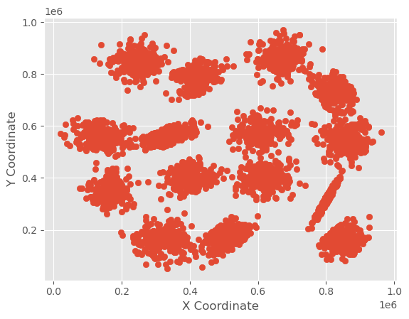

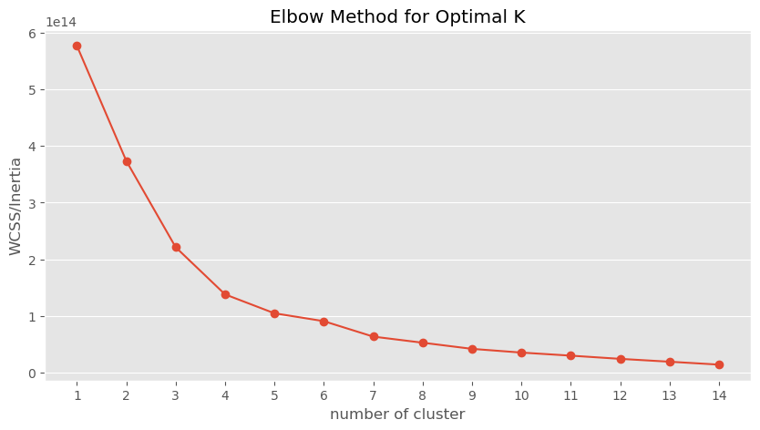

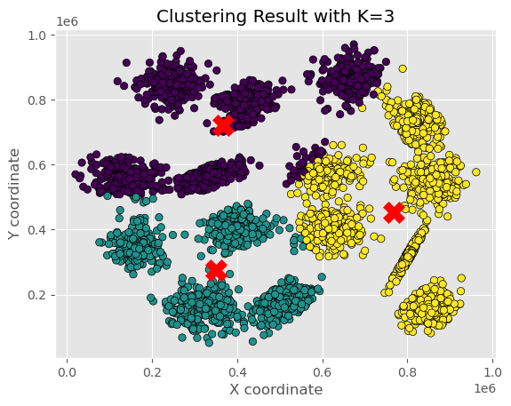

```python
from sklearn.cluster import KMeans

# Step 1: Load the Data
data = pd.read_csv("https://www.dropbox.com/s/wco3lxgn1f4a5k2/data_custering.csv?dl=1 ", header=None)
X = data.values  # Convert DataFrame to NumPy array

# Step 2: Visualize the Dataset
plt.scatter(data[0],data[1])
plt.xlabel("X Coordinate")
plt.ylabel("Y Coordinate")
plt.show()

# Step 3: K-Means Clustering and Inertia Calculation
wcss = []
for i in range(1,15):
    km = KMeans(n_clusters=i,init='k-means++')
    km.fit(data)
    wcss.append(km.inertia_)

# Step 4: Plot Inertia to Use the Elbow Method
plt.figure(figsize=(10,5))
plt.plot([i for i in range(1,15)],wcss,marker='o')
plt.xticks([i for i in range(1,15)])
plt.title("Elbow Method for Optimal K")
plt.xlabel("number of cluster")
plt.ylabel("WCSS/Inertia")
plt.grid(axis='x')
plt.show()


# Step 5: Choose an Optimal Number of Clusters (based on the Elbow plot)
Optimal_k_value = 3 # Replace with the K value you identify from the elbow plot
kmn = KMeans(n_clusters=Optimal_k_value, random_state=42)
data.columns = data.columns.astype(str)
clusters = kmn.fit_predict(data)


# Step 6: Visualize Clustering Results
plt.scatter(X[:, 0], X[:, 1], c=clusters, cmap='viridis', marker='o', edgecolor='k')
plt.scatter(kmn.cluster_centers_[:, 0], kmn.cluster_centers_[:, 1], s=300, c='red', marker='X')
plt.title(f"Clustering Result with K={Optimal_k_value}")
plt.xlabel("X coordinate")
plt.ylabel("Y coordinate")
plt.show()
```